# COMPUTATION BAYESIAN STATISTICS INCLUDING MARKOV CHAIN MONTE CARLO

28 Apr 2021 (*updated: 2021-04-28)*

## i. Admin & Startup

## Week 14 of 16 Focus

- Students draft Final Exam poster and get topic/data/plan approved.
- Read Ch.19, 20
- Practice on HW 12 Ch.19 1-5, due Friday Apr 30.
- Receive and act on HW 11 Ch.18 1-3 feedback.

## Today’s plan

- More final exam discussion and guidelines
- Discuss Ch.20
- End discussion via HW 12 Ch.19 1-5 hints.

*Please contribute questions and comments*

## II. Discuss Ch. 20 Comp Bayes with examples

## Visual Intro to MCMC

First let’s see some visualizations of sampling the posterior using different approaches:

[mcmc demo](https://chi-feng.github.io/mcmc-demo/)

## Sampling the posterior

Discuss Example 20.1

## An example of inverse probability sampling and computing

Xiang Li, A. Grant Schissler, Rui Wu, Lee Barford, and Frederick C. Harris, Jr. A graphical processing unit accelerated NORmal To Anything algorithm for high dimensional multivariate simulation *Advances in Intelligent Systems and Computing*, Volume 800, Chapter 46, pp 339-346. *Proceedings of the 16th International Conference on Information Technology : New Generations (ITNG 2019)* April 1-3, Las Vegas, NV.

## Acceptance–Rejection Sampling

Discuss the algorithm and example.

## Adaptive–Rejection Sampling

I’ll briefly mention the point of the section and move on.

## Section 20.2 Sampling Importance Resampling

Discuss text examples and figures briefly

## Section 20.3. Markov Chain Monte Carlo (MCMC) Methods

## The Metropolis-Hastings Algorithm (1970)

The *Metropolis-Hastings sampler* generates a Markov chain \(\{X_0, X_1, \ldots \}\) as follows:

1. Choose a proposal distribution \(g(\cdot | X_t)\), subject to regularity conditions discussed below.
2. Generate \(X_0\) from distribution \(g\).
3. Repeat (until chain has convergened to a stationary distribution):  
   A. Generate \(Y\) from \(g(\cdot | X_t)\).  
   B. Generate \(U\) from Uniform(0,1).  
   C. If  
   \[ U \leq \frac{f(Y)g(X_t|Y)}{f(X_t)g(Y|X_t)} \] accept \(Y\) and set \(X_{t+1} = Y\); otherwise set \(X_{t+1} = X_t\).  
   D. Increment \(t\).

So it is only necessary to know the density of the target distribution \(f\) up to a constant!

The algorithm is designed so that the stationary distribution of the chain is \(f\).

The proposal distribution must be chosen so that the generated chain will converge to a stationary distribution — the target distribution. A proposal distribution with the same support as the target distribution will generally satisify regularity conditions (irreducibility, positive recurrence, and aperiodicity) to guarantee convergence.

## The Metropolis Sampler (1953)

Note that Metropolis-Hastings is a generalized of the slightly older Metropolis algorithm.

In the Metropolis algorithm, proposal distribution \(g\) must be symmetric. I.e., \(g(X|Y)=g(Y|X)\).

Then the acceptance ratio

\[ r(X_t, Y) = \frac{f(Y)g(X_t|Y)}{f(X_t)g(Y|X_t)} \]

simplies to

\[ r(X_t, Y) = \frac{f(Y)}{f(X_t)}. \]

This generalization provides greater efficiency (more rapid convergence to the stationary distribution) in certain cases.

## Example from Rizzo 2006

Let’s use the M-H algorithm to generate a sample from the Rayleigh distribution. The Rayleigh distribution has density

\(f(x) = \frac{x}{\sigma^2}e^{-x^2/(2\sigma^2)}, x \geq 0, \sigma > 0\)

The Rayleigh distribution is used to model lifetimes subject to rapid aging. The mode is \(\sigma\), \(E[X] = \sigma \sqrt{\pi / 2}\) and \(Var(X) = \sigma^2 (4-\pi) /2\).

For the proposal distribution, try the chi-squared distribution with degrees of freedom of \(X_t\).

## Example from Rizzo 2006

```r
f <- function(x, sigma) {
    if (any(x < 0)) return(0)
    stopifnot(sigma > 0)
    return((x / sigma^2) * exp(-x^2 / (2*sigma^2)))
}
m <- 10000; sigma <- 4; x <- numeric(m)
x[1] <- rchisq(1, df = 1); k <- 0 ## rejections to investigate efficiency
u <- runif(m) ## acceptance probabilities
for (i in 2:m) {
    xt <- x[i-1]
    y <- rchisq(1, df = xt)
    num <- f(y, sigma) * dchisq(xt, df = y)
    den <- f(xt, sigma) * dchisq(y, df = xt)
    if (u[i] <= num/den) {
        x[i] <- y
    } else {
        ## y is rejected
        x[i] <- xt
        k <- k + 1
    }
}

print(k) / m
```

```
## [1] 4071
```

```
## [1] 0.4071
```

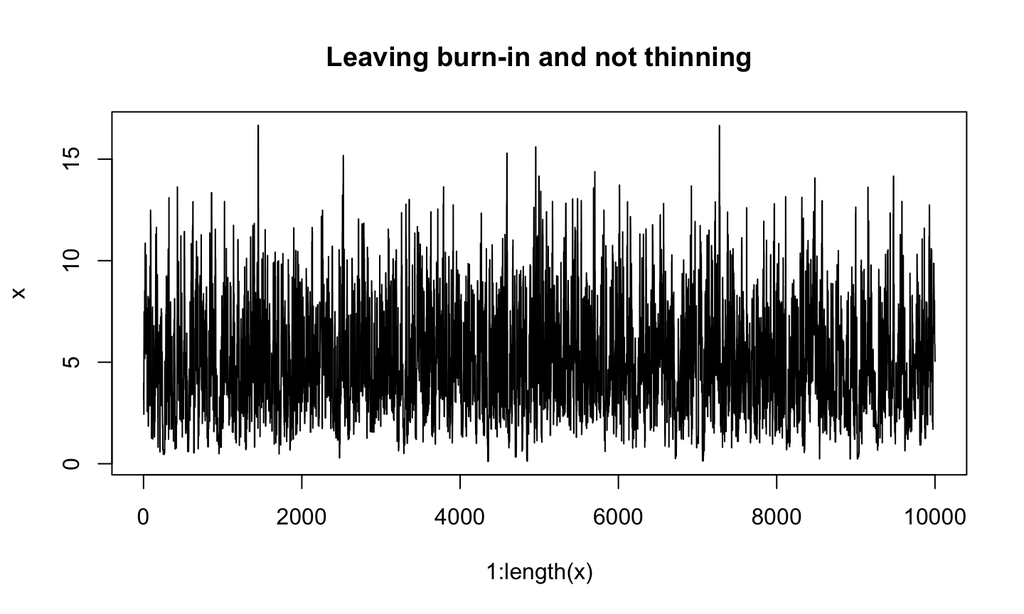

```r
## go past burn-in and thin
index <- seq(3000, 10000, by = 10)
y1 <- x[index]
plot(1:length(x), x, type = "l", main = "Leaving burn-in and not thinning", ylab = "x")
```

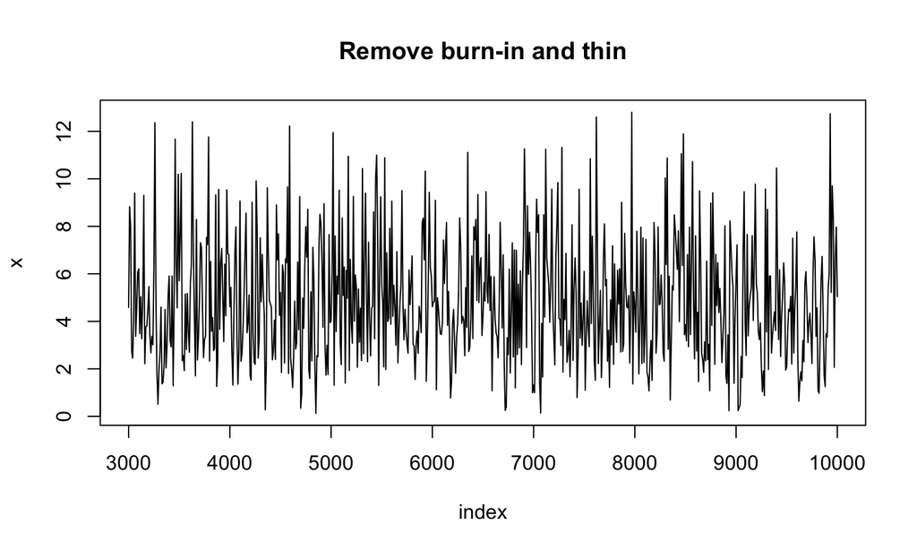

```r
plot(index, y1, type = "l", main = "Remove burn-in and thin", ylab = "x")
```

Check the expected value.

```r
## expected value
mean(y1)
```

```
## [1] 4.866845
```

```r
mean(x)
```

```
## [1] 4.926608
```

```r
## in theory
sigma * sqrt(pi /2)
```

```
## [1] 5.013257
```

## Gibbs Sampling

- Discuss big ideas of Gibbs Sampling and why it is important.

## Closing

3-2-1:

3 Techniques learned today  
2 New ideas you encountered  
1 Question you have